# Tarea BAIN 17/03/2022

Héctor Asorey de Pablos

2/3/2022

### Por favor asegúrate de tener **tu** ruta al espacio de trabajo R en el chunk siguiente

### Es buena práctica cargar al inicio las librerías necesarias para ejecutar el resto del markdown

```r
library(data.table)
library(stringr)
library(quanteda)
```

```r
library(quanteda.textplots)
library(quanteda.textstats)
library(topicmodels)
library(RColorBrewer)
library(wordcloud)
library(ggplot2)
```

# Objetivos de este documento RMarkdown y de la tarea

El objetivo de este documento es proporcionar instrucciones sobre la tarea evaluada #1 de la asignatura BAIN, y a la vez, proporcionar un esquema básico de análisis -al menos de los primeros pasos.

Es *crítico* que dispongas de los objetos R contenidos en los diferentes ficheros .rda subidos al Blackboard. (O que verifiques que tus objetos guardados a partir de las clases contienen la misma información).

# Tarea 1

Se trata de que realices un análisis comparativo de los tweets **sobre un tema de tu elección**. Como es evidente, será más interesante si se trata de un tema frecuente (“popular”) en el conjunto total de tweets, y quizás también polémico. Estos temas los puedes encontrar en los bi- y tri-gramas obtenidos en clases anteriores, y que puedes replicar a partir del código en BAIN_22_resumen_preproceso_para_tarea_1.rmd.

El proceso de trabajo sugerido (hay infinidad de maneras de abordarlo) es:

1. Extrae del dataframe con todos los tweets aquel subconjunto que contiene el tema (o temas) que te interesen.
2. Crea un corpus con ese subconjunto (y limpia la memoria para evitar colapsos) y añade los metadatos (docvars).
3. Limpia de stopwords y en general de aquellos tokens que no te añaden información o significado.
4. Genera bi- o tri-gramas a partir de los tokens limpiados y muestra la frecuencia relativa de los mismos.

Hasta aquí el resultado supone 5 puntos en el trabajo.

5. Genera los tokens por separado para distintas categorías de tweets (campo Category que se ha introducido como metadato), o por fechas (a partir de la fecha introducida como metadato) y haz una comparación entre ambos a partir de objetos bi- o tri-gramas.
6. Genera wordclouds comparativos y extrae conclusiones.

Estos dos puntos suponen otros 2 puntos adicionales al trabajo.

7. Realiza un análisis estadístico de corpus o genera tópicos (topicmining) como veremos en clase.
8. Realiza visualizaciones que permitan extraer conclusiones significativas a partir del proceso.

Estos dos puntos suponen otros 2 puntos (hasta 9 sobre 10) del trabajo.

Y un último punto lo otorgaré por la calidad general del documento entregado.

POR FAVOR LA ENTREGA DEBE SER UN RMARKDOWN *O* COMO ÚNICA ALTERNATIVA, UN SCRIPT .R CON UN .DOC O .PDF O .PPT ASOCIADO

Se pretende realizar un análisis del tema “Obama” en las elecciones estadounidenses del 2016.

En primer lugar, se debe cargar el objeto rda obtenido en clase.

```r
load("trollstot_dia4.rda")
```

Vamos a crear un objeto dfm a partir de una matriz general, en la cual solo almacenaremos aquellos registros en los cuales esté presente la palabra obama en el contenido.

Para trabajar mejor, y no preocuparnos por si está escrito “obama”, “Obama”, “OBAMA” o cualquier otra variación de mayúsculas y minúsculas, convertimos todo en la columna contenido a minúsculas.

```r
obama <- nuevo_objeto2[grep("obama", tolower(nuevo_objeto2$content)), ]

dim(obama)
```

```
## [1] 42412    14
```

Hemos obtenido una dfm con 42412 filas. Lo siguiente a hacer es convertir esa dfm a un corpus de quanteda.

```r
obama_corpus <- corpus(obama$content)
summary(obama_corpus)
```

|  | Text | Types | Tokens | Sentences |
| --- | --- | --- | --- | --- |
| 1 | text1 | 16 | 16 | 1 |
| 2 | text2 | 12 | 12 | 1 |
| 3 | text3 | 8 | 8 | 1 |
| 4 | text4 | 12 | 12 | 1 |
| 5 | text5 | 16 | 16 | 1 |
| 6 | text6 | 7 | 7 | 1 |
| 7 | text7 | 10 | 10 | 1 |
| 8 | text8 | 10 | 10 | 1 |
| 9 | text9 | 18 | 18 | 1 |
| 10 | text10 | 6 | 6 | 1 |

[output cut: 90 more lines]

Añadimos a este corpus los metadatos relevantes para el análisis, en este caso, la categoría del tweet (si es de izquierdas (LeftTroll), derechas(RightTroll), de incitacioón al miedo(FearMonger)…), si es un retweet y la fecha de publicación del tweet.

```r
docvars(obama_corpus,"Category") <- obama$account_category
docvars(obama_corpus,"Retweet") <- obama$retweet
docvars(obama_corpus,"Date_published") <- obama$publish_date
```

Una vez añadidos los metadatos al corpus, vamos a reducir los datos que vamos a tratar, creando un nuevo corpus a parir del anterior en el cual el metadato retweet es falso (igual a 0).

```r
obama_corpus_sin_retweets <- corpus_subset(obama_corpus, Retweet == 0)

length(obama_corpus)
```

```
## [1] 42412
```

```r
length(obama_corpus_sin_retweets)
```

```
## [1] 20651
```

Ahora, vamos a generar tokens a partir de ese corpus, para posteriormente ver cuáles son las palabras que más se repiten y más adelante hacer bigramas (dos tokens juntos) y trigramas (tres tokens juntos).

Añadimos la opción de “remove_punct” para que nos elimine los símbolos de exclamación (“!”, “¡”, “?”, “¿”), pero no activamos ni “remove_numbers” por si eliminasemos datos relevantes (por ejemplo un hashtag con alguna fecha) o remove_symbols, para no eliminar ni “#” ni “@” (topics y menciones de Twitter).

Los símbolos los trataremos con las stopwords.

```r
obama_tokens <- tokens(obama_corpus_sin_retweets, remove_punct = TRUE)
```

Vamos a eliminar de esos tokens estructuras muy repetidas pero sin valor significativo (preposiciones, construcciones…), y vamos a añadir algunas propias, como símbolos innecesarios para lograr mayor precisión en el análisis

```r
mystopwords <- c(stopwords("english"),
                 "im",
                 "t",
                 "r",
                 as.character(seq.int(from = 0, to = 9)),
                 "rt",
                 "|",
                 "/",
                 #Aqui antes habia una @
                 "\ ",
                 ".",
                 ",",
                 "_",
                 "'",
                 ";",
                 "`",
                 ":",
                 "~"
                 )
```

Creamos un conjunto de tokens sin las stopwords que hemos considerado.

```r
toks_nostop <- tokens_select(obama_tokens,
                             pattern = mystopwords,
                             selection = "remove")
```

Creamos bigramas de estos tokens

```r
bigramas_obama <- tokens_ngrams(toks_nostop, 2)
```

Convertimos esos bigramas a matrices dfm para poder hacer las wordclouds para ver estos datos de forma más gráfica

```r
matriz_obama_bi <- dfm(bigramas_obama)
topfeatures(matriz_obama_bi, 100)
```

```
##        president_obama           barack_obama                    u_s
##                    719                    611                    590
##           #world_#news         michelle_obama        #politics_obama
##                    545                    498                    491
##            white_house             obama_says   obama_administration
##                    438                    365                    329
##         #topnews_obama       obamacare_repeal          supreme_court
##                    309                    275                    263
##        #topvideo_obama            obama_visit            gun_control
##                    212                    175                    169
##           thanks_obama        hillary_clinton            state_union
##                    167                    136                    125
##           donald_trump             like_obama            obama_calls
##                    123                    121                    116
##          islamic_state       president_barack             obama_said
##                    114                    111                    108
##              iran_deal          clinton_obama            obama_wants
##                    104                    104                    101
##              obama_era            malia_obama      obama_immigration
##                     94                     93                     93
##            health_care            obama_urges          obama_clinton
##                     90                     89                     88
##   #cleveland_#politics          obama_hillary         climate_change
##                     86                     85                     84
##           obama_legacy            obama_admin       repeal_obamacare
##                     83                     80                     79
##            #tcot_#ccot             obama_just              obama_gun
##                     77                     73                     72
##          obama_defends           latest_obama        president_trump
##                     70                     70                     69
##   #rt_@fallenangelmovi             says_obama        syrian_refugees
##                     68                     68                     67
##       obama_presidency           former_obama             first_lady
##                     67                     66                     66
##            obama_trump            middle_east        obama_president
##                     63                     62                     61
##           obama_visits            obama_tells             trade_deal
##                     61                     59                     59
##           #tcot_#pjnet            obama_still           obama_leaves
##                     58                     57                     56
```

[output cut: 13 more lines]

```
##                     47                     46                     46
## @fallenangelmovi_#tcot            think_obama            obama_heads
##                     46                     46                     46
##          another_obama             pres_obama             #topnews_u
##                     45                     45                     45
##        obama_#politics             ben_carson             obama_make
##                     45                     44                     44
##              obama_can         foreign_policy            final_state
##                     44                     44                     43
##          united_states            obama_hails            obama_final
##                     43                     43                     43
##              obama_now             susan_rice             obama_left
##                     43                     42                     42
##                obama_s
##                     42
```

Creamos trigramas a partir de los tokens

```r
trigramas_obama <- tokens_ngrams(toks_nostop, 3)
```

Convertimos los trigramas a una matriz dfm, para su posterior visualizacion en wordclouds

```r
matriz_obama_tri <- dfm(trigramas_obama)
topfeatures(matriz_obama_tri, 100)
```

```
##               president_barack_obama           #rt_@fallenangelmovi_#tcot
##                                  107                                   46
##                         #topnews_u_s                    iran_nuclear_deal
##                                   45                                   43
##                    obama_white_house                    final_state_union
##                                   40                                   39
##           cover_#rt_@fallenangelmovi                  obama_leaves_office
##                                   39                                   38
##                   white_house_#world                   house_#world_#news
##                                   36                                   36
##                    white_house_#news              killed_obamacare_repeal
##                                   36                                   34
##         @fallenangelmovi_#tcot_#ccot                             says_u_s
##                                   34                                   34
##         #politics_#conservative_#usa               obama_immigration_plan
##                                   33                                   29
##          #conservative_#usa_#america                  state_union_address
##                                   29                                   28
##               clinton_obama_benghazi                 obama_benghazi_style
##                                   28                                   28
##                 benghazi_style_cover                      style_cover_#rt
##                                   28                                   28
##                           u_s_troops    #teapartynews_#teaparty_#politics
##                                   28                                   28
##    #teaparty_#politics_#conservative           #usa_#america_#libertarian
##                                   28                                   28
##        #america_#libertarian_#nobama    #libertarian_#nobama_#wethepeople
##                                   28                                   28
##        #nobama_#wethepeople_#patriot               mccain_voted_obamacare
##                                   28                                   27
##               voted_obamacare_repeal                            obama_u_s
##                                   27                                   27
##                              u_s_top                          s_top_court
##                                   26                                   26
##                   visit_#world_#news                supreme_court_nominee
##                                   26                                   26
##                 barack_hussein_obama                  #topnews_obama_says
##                                   26                                   25
##                 video_trump_condemns                  trump_condemns_hate
##                                   24                                   24
```

[output cut: 45 more lines]

```
##                                   19                                   19
##               official_admits_defeat                      admits_defeat_n
##                                   19                                   19
##                       defeat_n_korea                      left_trump_well
##                                   19                                   19
##                    trump_well_funded                  well_funded_nuclear
##                                   19                                   19
##                  funded_nuclear_mess                    nuclear_mess_iran
##                                   19                                   19
##               mcmaster_fighting_keep                  fighting_keep_obama
##                                   19                                   19
##                    keep_obama_legacy                   obama_legacy_alive
##                                   19                                   19
## expresses_sympathies_charlottesville     sympathies_charlottesville_worst
##                                   19                                   19
```

Wordcloud de los trigramas. Mostramos solo los 50 trigramas más recurrentes.

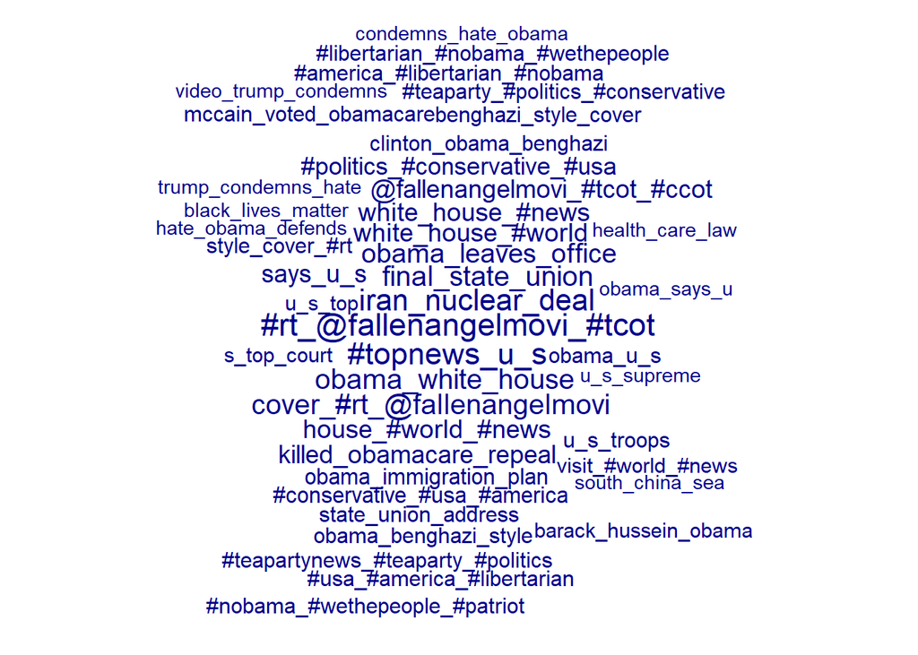

```r
textplot_wordcloud(matriz_obama_tri, rotation = 0, max_words = 50)
```

A partir de aquí, ya podemos empezar a sacar algunas conclusiones, analizando los temas por separado: -obamacare es un sistema de “salud pública” estadounidense aprobado por Obama, el cual Trump quería derogar. -BlackLivesMatter es un movimiento social, el cual busca la igualdad entre negros y blancos en EEUU. Tomó gran relevancia en 2020, con la muerte de George Floyd a manos de la policía. -Benghazi, o en español Bengasi, es una ciudad de Libia. En 2012 un grupo paramilitar islámico atacó dos edificios estadounidenses, un consulado y un edificio de la CIA, y donde se desplegó un equipo de operaciones especiales americano. Hubo cuatro fallecidos estadounidenses, entre ellos el embajador en Libia. Esto provocó una división política en EEUU, en el que los republicanos acusaron a Hillary Clinton (por entonces Secretaria de Estado con Obama) de una lenta respuesta militar. -Irán. Obama logró el pacto nuclear con Irán, por el cual este país renunciaba a desarrollar armas nucleares y las sanciones económicas impuestas por EEUU y la UE serían levantadas. Este pacto se creó en 2015, poniéndose en marcha en 2016. Con la administración Trump, este pacto se abandonó. -TeaParty es un movimiento conservador dentro del partido republicano

Como podemos ver, aparecen temas políticamente muy importantes y controvertidos, de los cuales los rusos supieron aprovecharse para inferir en las elecciones del 2016

Wordcloud de los bigramas. Mostramos los 100 bigramas más recurrentes.

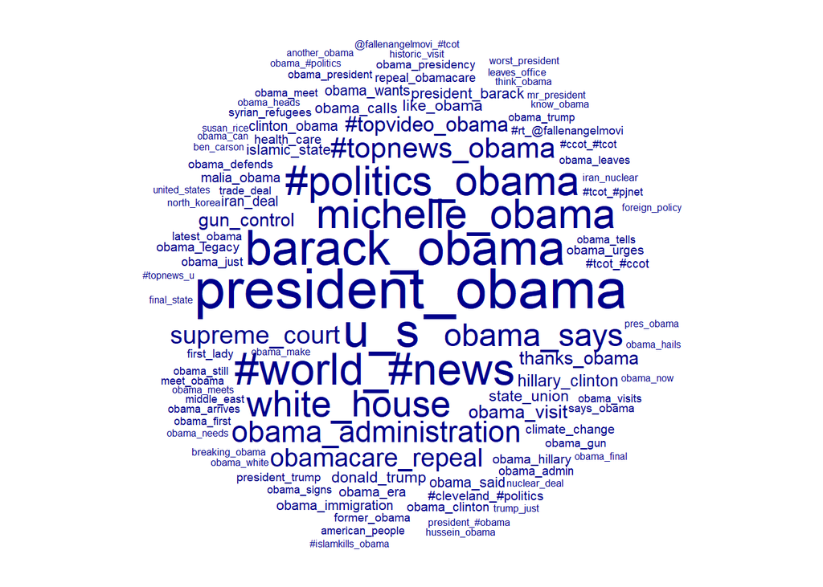

```r
textplot_wordcloud(matriz_obama_bi, rotation = 0, max_words = 100)
```

Como podemos ver, en los bigramas también se encuentran temas muy relevantes: -Obama, presidente de los Estados Unidos durante dos legislaturas, el máximo estipulado por la Constitución de EEUU que alguien puede ser presidente. Si hablamos de Obama, está claro que tenía que tener mucha relevancia como muestra el word cloud. -Hillary Clinton, Secretaria de Estado con Obama entre 2009 y 2013, y candidata a las elecciones de 2016, que recibió el apoyo de Obama. -Gun Control (Control de armas). Obama era defensor de aprobar un control más estricto sobre las armas, debido a tiroteos, entre los que destacan infamemente los escolares. Idea contraria a los republicanos. -Donald Trump. Presidente de los EEUU tras Obama, al cual Trump tenía mucho desprecio. -Islamic State. Durante esos años se vivieron muchos atentados terroristas en Europa por parte del ISIS. Esto lo usaría Trump para justificar su política migratoria, en la cual Trump quiso impedir la entrada a EEUU de cualquier persona de religión musulmana. Este veto fue bloqueado por tribunales en distintos estados, aunque finalmente lo avaló el Tribunal Supremo.

Se pueden ver temas vistos anteriormente en los trigramas como el “healthcare/obamacare”, “iran nuclear”…

Diferenciamos ahora las palabras que más se repiten distinguiendo por categoría los tweets. De esta manera podemos comparar qué utilizaban los trolls de izquierdas y qué utilizaban los trolls de derechas.

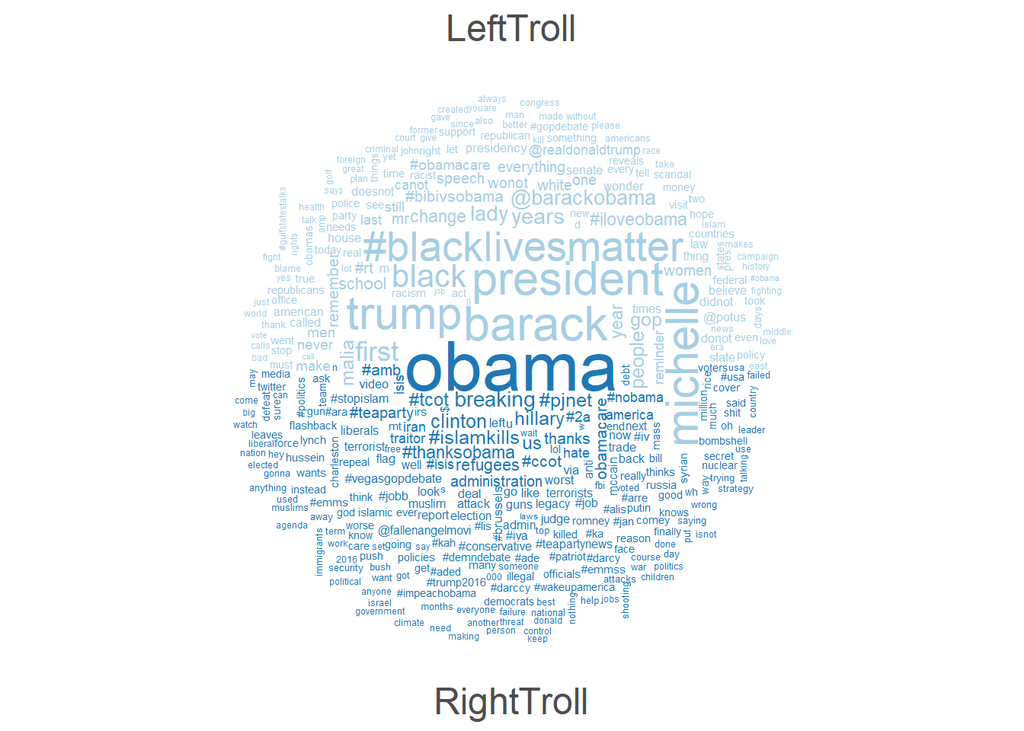

```r
corpus_subset(obama_corpus_sin_retweets,
              Category %in% c("RightTroll", "LeftTroll")) %>%
    tokens(remove_punct = TRUE) %>%
    tokens_remove(mystopwords) %>%
    dfm() %>%
    dfm_group(groups = Category) %>%
    dfm_trim(min_termfreq = 50, verbose = FALSE) %>%
    textplot_wordcloud(comparison = TRUE)
```

Podemos ver que los trolls de izquierdas referenciaban temas más progresistas, como puede ser el “BlackLivesMatter” o el “I Love Obama”, ya que, por analogía con la política española, los demócratas serían de izquierdas y los republicanos de derechas.

Por otro lado, desde los trolls de derechas podemos ver “teaparty”, “muslim”, “Putin”, “IslamKills”, “terrorist”, “trump 2016”…

Comparemos ahora las categorias “RightTroll”, “LeftTroll” y “NewsFeed”. Asumo que la categoría “NewsFeed” hace referencia a tweets publicados por la prensa.

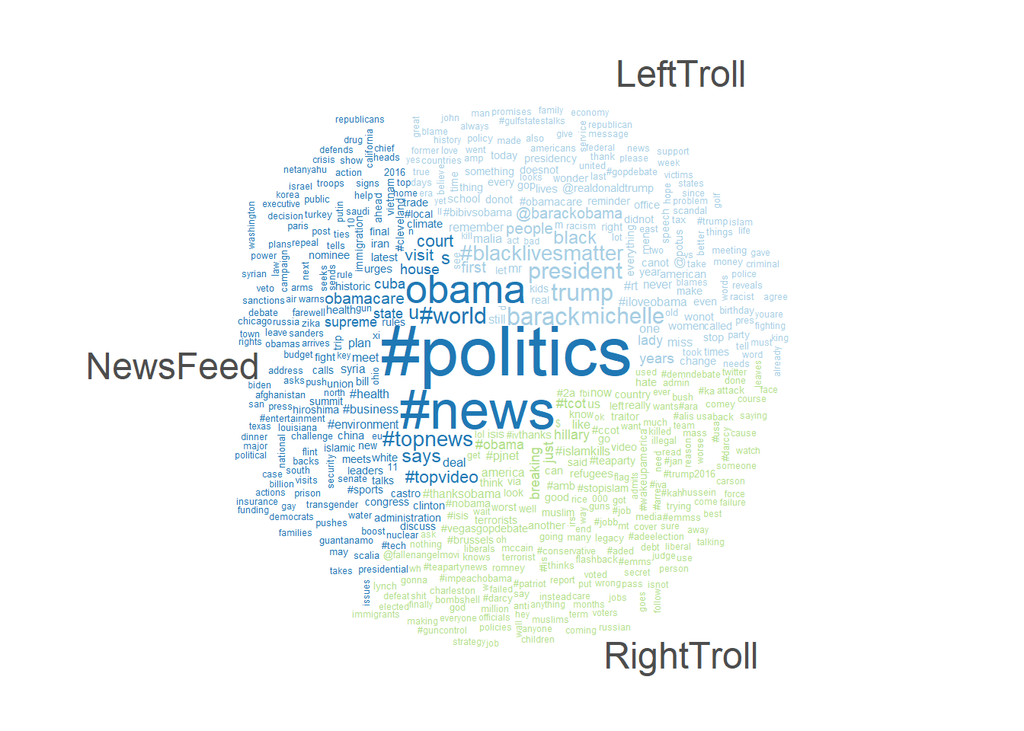

```r
corpus_subset(obama_corpus_sin_retweets,
              Category %in% c("RightTroll", "LeftTroll", "NewsFeed")) %>%
    tokens(remove_punct = TRUE) %>%
    tokens_remove(mystopwords) %>%
    dfm() %>%
    dfm_group(groups = Category) %>%
    dfm_trim(min_termfreq = 50, verbose = FALSE) %>%
    textplot_wordcloud(comparison = TRUE)
```

Ahora veremos cuánta importancia tiene cada categoría. Empezemos por los trolls de derechas

```r
obama_rightTrolls <- corpus_subset(obama_corpus_sin_retweets, Category == "RightTroll")

ndoc(obama_rightTrolls)
```

```
## [1] 11014
```

```r
ndoc(obama_rightTrolls)/ndoc(obama_corpus_sin_retweets)
```

```
## [1] 0.5333398
```

Como podemos ver, los trolls de derechas tienen una gran importancia en el tema Obama, lo cual tiene mucho sentido, ya que, como hemos mencionado antes, Obama sería de izquierdas y lo más lógico es atacarle desde una idealogía de derechas.

```r
obama_leftTrolls <- corpus_subset(obama_corpus_sin_retweets, Category == "LeftTroll")

length(obama_leftTrolls)
```

```
## [1] 836
```

```r
ndoc(obama_leftTrolls)/ndoc(obama_corpus_sin_retweets)
```

```
## [1] 0.0404823
```

Sin embargo, los trolls de izquierdas son irrelevantes en comparación con los de derechas, por lo expuesto anteriormente.

```r
obama_newsfeed <- corpus_subset(obama_corpus_sin_retweets, Category == "NewsFeed")

length(obama_newsfeed)
```

```
## [1] 7742
```

```r
ndoc(obama_newsfeed)/ndoc(obama_corpus_sin_retweets)
```

```
## [1] 0.3748971
```

Como podemos ver, News Feed también tiene mucha importancia

```r
obama_fearmonger <- corpus_subset(obama_corpus_sin_retweets, Category == "Fearmonger")

length(obama_fearmonger)
```

```
## [1] 105
```

```r
ndoc(obama_fearmonger)/ndoc(obama_corpus_sin_retweets)
```

```
## [1] 0.0050845
```

FearMonger por el contrario, es irrelevante.

Vamos ahora a realizar un wordcloud usando topicmodels. Primero vamos a ver qué temas (primero con los bigramas) son importantes previos a las elecciones estadounidenses del 8 de noviembre de 2016.

Vamos a guadarlo en una imagen png para poder visualizarlo mejor

```r
right_tokens_bigrams <- tokens_subset(bigramas_obama,
                                      (Category == "RightTroll" &
                                        Date_published < '2016-11-08'))


matrizObamaAux <- dfm(right_tokens_bigrams)

quant_dfm <- dfm_trim(matrizObamaAux,
                      min_termfreq = 10)

set.seed(100)
if (require(topicmodels)) {
   my_lda_fit12 <- LDA(convert(quant_dfm, to = "topicmodels"),
                       k = 8)
   get_terms(my_lda_fit12, 5)
}
```

```
##      Topic 1            Topic 2           Topic 3
## [1,] "president_obama"  "hillary_clinton" "know_obama"
## [2,] "obama_presidency" "white_house"     "donald_trump"
## [3,] "@beny_benson"     "obama_can"       "#politics_#conservative"
## [4,] "leaves_office"    "think_obama"     "#conservative_#usa"
## [5,] "right_now"        "obama_s"         "obama_needs"
##      Topic 4         Topic 5                Topic 6
## [1,] "barack_obama"  "obama_administration" "#tcot_#ccot"
## [2,] "like_obama"    "gun_control"          "obama_wants"
## [3,] "obama_said"    "u_s"                  "#rt_@fallenangelmovi"
## [4,] "obama_hillary" "palm_springs"         "clinton_obama"
## [5,] "#ccot_#tcot"   "obama_trying"         "#tcot_#pjnet"
##      Topic 7                  Topic 8
## [1,] "obama_says"             "michelle_obama"
## [2,] "syrian_refugees"        "thanks_obama"
## [3,] "#islamkills_obama"      "hussein_obama"
## [4,] "worst_president"        "president_#obama"
## [5,] "#islamkills_#stopislam" "middle_east"
```

```r
kk <- my_lda_fit12@beta
# Generamos una matriz de dimensiÃ³n k (tÃ³picos) = 12 y n tokens (70k)
class(kk)
```

```
## [1] "matrix" "array"
```

```r
dim(kk)
```

```
## [1]   8 403
```

```r
# Para poder dibujar los wordclouds ponemos el token como nombre de columna
colnames(kk) <- my_lda_fit12@terms
kk[, 5:10]
```

```
##      @fallenangelmovi_#ccot #ccot_#tcot #tcot_#teaparty mt_@angelacarwile
## [1,]            -288.352080 -165.386169     -295.163730       -399.145540
## [2,]            -284.577030 -162.470839     -185.612202       -395.612380
## [3,]            -276.817149 -209.628033     -287.108846       -389.223223
## [4,]              -3.886282   -2.969991      -39.120560       -405.183847
## [5,]            -285.339690 -130.891998     -289.499979       -380.076569
## [6,]             -31.855783  -91.563766       -3.487671       -399.531958
## [7,]            -284.274958 -252.910809     -291.727936         -4.606172
## [8,]            -297.681439 -264.787024     -303.442806       -411.090232
##      @angelacarwile_levin levin_obama
## [1,]          -399.784301 -400.719745
## [2,]          -396.086421 -396.549379
## [3,]          -392.281823 -390.591602
## [4,]          -404.344376 -405.766715
## [5,]          -381.398235 -382.333128
## [6,]          -402.945013 -401.066320
## [7,]            -4.606172   -4.606172
## [8,]          -411.733205 -411.515815
```

```r
#head(kk)

# We define the matrix of plots
# How to do this well explained here
# http://www.statmethods.net/advgraphs/layout.html
# 2 colums * 1500 = 3000 width
# 4 rows * 800 = 3200 height

png(file="ObamaRightTrollsBeforeElections.png",
    width=3000,
    height=3200,
    res = 300,
    bg = "black")

par(mfrow=c(4, 2))

for (k in 1:length(kk[,1])) {

  topic1 <- kk[k,]

  v <- topic1

  # utilizando rank pasamos el beta numÃ©rico a orden (entero, positivo)
  d <- data.frame(word = names(v), rank= rank(v))

  # ordenamos descendente (por defecto -sin el "-" es ascendente)
  d <- d[order(-d$rank),]

  # normalizamos (parecido a una frecuencia de palabras) +100 para que tenga rango amplio
  d$freq <- d$rank - max(d$rank) + 100

    # Now with a prettier layout
  # baed on code published in
  # http://onertipaday.blogspot.com.es/2011/07/word-cloud-in-r.html
  #plot.new()

  pal2 <- brewer.pal(11,"Spectral")
  wordcloud(d$word,
            d$freq,
# scale nos da la diferencia relativa (mÃ¡x mÃn) entre tamaÃ±os de palabras
            scale = c(1.2, 0.05),
# max.words las que quepan
            max.words = 100,
            random.order = FALSE,
            rot.per = 0,
            colors = pal2,
            random.color = TRUE)
  title(main = paste(k),
        font = 10,
        col.main = "yellow")
}


dev.off()
```

A continuación haré lo mismo, pero con los tweets de trolls de derechas tras las elecciones

```r
right_tokens_bigrams_after <- tokens_subset(bigramas_obama,
                                      (Category == "RightTroll" &
                                        Date_published >= '2016-11-08'))


matrizObamaAuxAfter <- dfm(right_tokens_bigrams_after)

quant_dfm <- dfm_trim(matrizObamaAuxAfter,
                      min_termfreq = 10)

set.seed(100)
if (require(topicmodels)) {
   my_lda_fit12 <- LDA(convert(quant_dfm, to = "topicmodels"),
                       k = 8)
   get_terms(my_lda_fit12, 5)
}
```

```
##      Topic 1            Topic 2            Topic 3
## [1,] "obamacare_repeal" "repeal_obamacare" "president_trump"
## [2,] "president_obama"  "video_trump"      "breaking_obama"
## [3,] "white_house"      "hate_obama"       "malia_obama"
## [4,] "breaking_trump"   "watch_obama"      "viral_video"
## [5,] "traitor_mccain"   "trump_condemns"   "via_@truthfeednews"
##      Topic 4            Topic 5        Topic 6           Topic 7
## [1,] "barack_obama"     "obama_era"    "trump_just"      "michelle_obama"
## [2,] "american_people"  "obama_legacy" "u_s"             "obama_administration"
## [3,] "obamacare_repeal" "donald_trump" "obama_clinton"   "obama_admin"
## [4,] "obama_just"       "keep_obama"   "bombshell_obama" "another_obama"
## [5,] "federal_judge"    "obama_deal"   "obama_left"      "report_obama"
##      Topic 8
## [1,] "susan_rice"
## [2,] "former_obama"
## [3,] "obamacare_repeal"
## [4,] "mccain_voted"
## [5,] "voted_obamacare"
```

```r
kk <- my_lda_fit12@beta
# Generamos una matriz de dimensiÃ³n k (tÃ³picos) = 12 y n tokens (70k)
class(kk)
```

```
## [1] "matrix" "array"
```

```r
dim(kk)
```

```
## [1]   8 440
```

```r
# Para poder dibujar los wordclouds ponemos el token como nombre de columna
colnames(kk) <- my_lda_fit12@terms
kk[, 5:10]
```

```
##      just_threw threw_obama  obama_bus trump_considering considering_brilliant
## [1,] -234.77375  -234.77375 -234.77375       -235.053686           -235.011003
## [2,] -234.19559  -208.12547 -208.12547       -234.475526           -234.432843
## [3,] -234.55799  -234.55799 -234.55799       -234.837927           -234.795244
## [4,] -234.60698  -234.60698 -234.60698         -3.823512             -3.774721
## [5,] -234.54321  -234.54321 -234.54321       -234.823141           -234.780459
## [6,] -234.29542  -234.29542 -234.29542       -234.575353           -234.532670
## [7,] -234.55764  -234.55764 -234.55764       -234.837580           -234.794897
## [8,]   -3.83071    -3.83071   -3.83071       -235.166852           -235.124169
##      brilliant_strategy
## [1,]        -235.011003
## [2,]        -234.432843
## [3,]        -234.795244
## [4,]          -3.774721
## [5,]        -234.780459
## [6,]        -234.532670
## [7,]        -234.794897
## [8,]        -235.124169
```

```r
#head(kk)

# We define the matrix of plots
# How to do this well explained here
# http://www.statmethods.net/advgraphs/layout.html
# 2 colums * 1500 = 3000 width
# 4 rows * 800 = 3200 height

png(file="obamaRightTrollsAfterElections.png",
    width=3000,
    height=3200,
    res = 300,
    bg = "black")

par(mfrow=c(4, 2))

for (k in 1:length(kk[,1])) {

  topic1 <- kk[k,]

  v <- topic1

  # utilizando rank pasamos el beta numÃ©rico a orden (entero, positivo)
  d <- data.frame(word = names(v), rank= rank(v))

  # ordenamos descendente (por defecto -sin el "-" es ascendente)
  d <- d[order(-d$rank),]

  # normalizamos (parecido a una frecuencia de palabras) +100 para que tenga rango amplio
  d$freq <- d$rank - max(d$rank) + 100

    # Now with a prettier layout
  # baed on code published in
  # http://onertipaday.blogspot.com.es/2011/07/word-cloud-in-r.html
  #plot.new()

  pal2 <- brewer.pal(11,"Spectral")
  wordcloud(d$word,
            d$freq,
# scale nos da la diferencia relativa (mÃ¡x mÃn) entre tamaÃ±os de palabras
            scale = c(1.2, 0.05),
# max.words las que quepan
            max.words = 100,
            random.order = FALSE,
            rot.per = 0,
            colors = pal2,
            random.color = TRUE)
  title(main = paste(k),
        font = 10,
        col.main = "yellow")
}


dev.off()
```

Destacaré ahora temas que no habían salido hasta ahora.

Destaco a título personal el tema “mad max”. Me ha sorprendido mucho ver una película clásica como tema, pero he entendido su significado dentro del contexto del pacto nuclear con Irán. Los sucesos de Mad Max ocurrían en el Páramo, una tierra desolada tras una guerra nuclear.

Añadir que tanto previo como tras las elecciones, un tema recurrente es Donald Trump (“president_trump”, “donald_trump”…).

A continuación, se va a repetir este mismo proceso, pero esta vez con trigramas. Empezaré de nuevo por los tweets previos a las elecciones de 2016.

```r
right_tokens_trigrams_before <- tokens_subset(trigramas_obama,
                                      (Category == "RightTroll" &
                                        Date_published < '2016-11-08'))


matrizObamaAuxTriBefore <- dfm(right_tokens_trigrams_before)

quant_dfm <- dfm_trim(matrizObamaAuxTriBefore,
                      min_termfreq = 10)

set.seed(100)
if (require(topicmodels)) {
   my_lda_fit12 <- LDA(convert(quant_dfm, to = "topicmodels"),
                       k = 8)
   get_terms(my_lda_fit12, 5)
}
```

```
##      Topic 1                        Topic 2
## [1,] "#rt_@fallenangelmovi_#tcot"   "barack_hussein_obama"
## [2,] "@fallenangelmovi_#tcot_#ccot" "#pjnet_#ccot_#tcot"
## [3,] "cover_#rt_@fallenangelmovi"   "#2a_#nra_#pjnet"
## [4,] "clinton_obama_benghazi"       "threat_u_s"
## [5,] "obama_benghazi_style"         "obama_hillary_clinton"
##      Topic 3                             Topic 4
## [1,] "#patriot_#conservative_#politics"  "#politics_#conservative_#usa"
## [2,] "#conservative_#politics_#teaparty" "#conservative_#usa_#america"
## [3,] "#politics_#teaparty_#republican"   "#teapartynews_#teaparty_#politics"
## [4,] "#teaparty_#republican_#democrat"   "#teaparty_#politics_#conservative"
## [5,] "#republican_#democrat_#2a"         "#usa_#america_#libertarian"
##      Topic 5                        Topic 6
## [1,] "president_barack_obama"       "#rt_@fallenangelmovi_#ccot"
## [2,] "obama_leaves_office"          "@fallenangelmovi_#ccot_#tcot"
## [3,] "unlike_obama_#vegasgopdebate" "obama_worst_president"
## [4,] "president_united_states"      "#ccot_#tcot_#teaparty"
## [5,] "@beny_benson_#obama"          "#jebwecan_#ilovehillary_#iloveobama"
##      Topic 7                            Topic 8
## [1,] "massive_clinton_obama"            "fought_amnesty_obamacare"
## [2,] "clinton_obama_cover"              "mt_@peddoc63_#tedcruz"
## [3,] "#rt_@fallenangelmovi_#tcot"       "@peddoc63_#tedcruz_fought"
## [4,] "@fallenangelmovi_#tcot_#teaparty" "#tedcruz_fought_amnesty"
## [5,] "#tcot_#teaparty_#ccot"            "amnesty_obamacare_#2a"
```

```r
kk <- my_lda_fit12@beta
# Generamos una matriz de dimensiÃ³n k (tÃ³picos) = 12 y n tokens (70k)
class(kk)
```

```
## [1] "matrix" "array"
```

```r
dim(kk)
```

```
## [1]   8 108
```

```r
# Para poder dibujar los wordclouds ponemos el token como nombre de columna
colnames(kk) <- my_lda_fit12@terms
kk[, 5:10]
```

```
##      @angelacarwile_levin_obama levin_obama_cry obama_cry_#rebootliberty
## [1,]                -596.350110     -596.350110              -596.350110
## [2,]                -525.833559     -525.833559              -525.833559
## [3,]                  -3.095578       -3.095578                -3.095578
## [4,]                -527.507703     -527.507703              -527.507703
## [5,]                -526.904455     -526.904455              -526.904455
## [6,]                -526.517224     -526.517224              -526.517224
## [7,]                -523.944349     -523.944349              -523.944349
## [8,]                -596.350110     -596.350110              -596.350110
##      cry_#rebootliberty_#wakeupamerica #rebootliberty_#wakeupamerica_#pjnet
## [1,]                       -596.350110                          -452.538579
## [2,]                       -525.833559                          -382.292366
## [3,]                         -3.095578                            -2.759105
## [4,]                       -527.507703                          -452.062028
## [5,]                       -526.904455                          -383.006297
## [6,]                       -526.517224                          -382.748143
## [7,]                       -523.944349                          -381.032893
## [8,]                       -596.350110                          -452.538579
##      #pjnet_#ccot_#tcot
## [1,]        -380.756229
## [2,]          -2.214616
## [3,]        -380.215322
## [4,]        -380.374988
## [5,]        -379.972824
## [6,]        -379.714669
## [7,]        -309.819177
## [8,]        -380.756229
```

```r
#head(kk)

# We define the matrix of plots
# How to do this well explained here
# http://www.statmethods.net/advgraphs/layout.html
# 2 colums * 1500 = 3000 width
# 4 rows * 800 = 3200 height

png(file="obamaRightTrollsBeforeElectionsTrigrama.png",
    width=5000,
    height=5000,
    res = 300,
    bg = "black")

par(mfrow=c(4, 2))

for (k in 1:length(kk[,1])) {

  topic1 <- kk[k,]

  v <- topic1

  # utilizando rank pasamos el beta numÃ©rico a orden (entero, positivo)
  d <- data.frame(word = names(v), rank= rank(v))

  # ordenamos descendente (por defecto -sin el "-" es ascendente)
  d <- d[order(-d$rank),]

  # normalizamos (parecido a una frecuencia de palabras) +100 para que tenga rango amplio
  d$freq <- d$rank - max(d$rank) + 100

    # Now with a prettier layout
  # baed on code published in
  # http://onertipaday.blogspot.com.es/2011/07/word-cloud-in-r.html
  #plot.new()

  pal2 <- brewer.pal(11,"Spectral")
  wordcloud(d$word,
            d$freq,
# scale nos da la diferencia relativa (mÃ¡x mÃn) entre tamaÃ±os de palabras
            scale = c(1.2, 0.05),
# max.words las que quepan
            max.words = 50,
            random.order = FALSE,
            rot.per = 0,
            colors = pal2,
            random.color = TRUE)
  title(main = paste(k),
        font = 10,
        col.main = "yellow")
}


dev.off()
```

Ahora veremos los trigramas populares tras las elecciones

```r
right_tokens_trigrams_after <- tokens_subset(trigramas_obama,
                                      (Category == "RightTroll" &
                                        Date_published >= '2016-11-08'))


matrizObamaAuxTriAfter <- dfm(right_tokens_trigrams_after)

quant_dfm <- dfm_trim(matrizObamaAuxTriAfter,
                      min_termfreq = 10)

set.seed(100)
if (require(topicmodels)) {
   my_lda_fit12 <- LDA(convert(quant_dfm, to = "topicmodels"),
                       k = 8)
   get_terms(my_lda_fit12, 5)
}
```

```
##      Topic 1                  Topic 2
## [1,] "video_trump_condemns"   "considering_brilliant_strategy"
## [2,] "trump_condemns_hate"    "brilliant_strategy_still"
## [3,] "condemns_hate_obama"    "strategy_still_pass"
## [4,] "hate_obama_defends"     "still_pass_obamacare"
## [5,] "comparison_video_trump" "pass_obamacare_repeal"
##      Topic 3                 Topic 4
## [1,] "drops_bombshell_obama" "watch_obama_defend"
## [2,] "carson_ending_illegal" "obama_defend_isis"
## [3,] "ending_illegal_obama"  "defend_isis_attack"
## [4,] "illegal_obama_hud"     "isis_attack_christianity"
## [5,] "obama_hud_scam"        "flashback_watch_obama"
##      Topic 5                                Topic 6
## [1,] "expresses_sympathies_charlottesville" "mccain_voted_obamacare"
## [2,] "sympathies_charlottesville_worst"     "voted_obamacare_repeal"
## [3,] "charlottesville_worst_way"            "pressure_liar_susan"
## [4,] "worst_way_possible"                   "liar_susan_rice"
## [5,] "obama_expresses_sympathies"           "susan_rice_just"
##      Topic 7                    Topic 8
## [1,] "breaking_former_obama"    "trump_just_shredded"
## [2,] "report_cowardly_obama"    "just_shredded_hell"
## [3,] "cowardly_obama_feared"    "shredded_hell_obama"
## [4,] "obama_feared_retaliation" "whoa_trump_just"
## [5,] "deal_fail_iran"           "gop_failure_repeal"
```

```r
kk <- my_lda_fit12@beta
# Generamos una matriz de dimensiÃ³n k (tÃ³picos) = 12 y n tokens (70k)
class(kk)
```

```
## [1] "matrix" "array"
```

```r
dim(kk)
```

```
## [1]   8 318
```

```r
# Para poder dibujar los wordclouds ponemos el token como nombre de columna
colnames(kk) <- my_lda_fit12@terms
kk[, 5:10]
```

```
##      just_threw_obama threw_obama_bus trump_considering_brilliant
## [1,]      -100.000000     -100.000000                 -208.464528
## [2,]      -100.000000     -100.000000                   -3.097837
## [3,]      -100.000000     -100.000000                 -208.320836
## [4,]      -100.000000     -100.000000                 -208.313706
## [5,]      -100.000000     -100.000000                 -208.374435
## [6,]        -3.338984       -3.338984                 -208.371063
## [7,]      -100.000000     -100.000000                 -100.000000
## [8,]      -100.000000     -100.000000                 -100.000000
##      considering_brilliant_strategy brilliant_strategy_still
## [1,]                    -208.454062              -208.454062
## [2,]                      -3.049047                -3.049047
## [3,]                    -208.310370              -208.310370
## [4,]                    -208.303239              -208.303239
## [5,]                    -208.363969              -208.363969
## [6,]                    -208.360597              -208.360597
## [7,]                    -100.000000              -100.000000
## [8,]                    -100.000000              -100.000000
##      strategy_still_pass
## [1,]         -208.454062
## [2,]           -3.049047
## [3,]         -208.310370
## [4,]         -208.303239
## [5,]         -208.363969
## [6,]         -208.360597
## [7,]         -100.000000
## [8,]         -100.000000
```

```r
#head(kk)

# We define the matrix of plots
# How to do this well explained here
# http://www.statmethods.net/advgraphs/layout.html
# 2 colums * 1500 = 3000 width
# 4 rows * 800 = 3200 height

png(file="obamaRightTrollsAfterElectionsTrigrama.png",
    width=5000,
    height=5000,
    res = 300,
    bg = "black")

par(mfrow=c(4, 2))

for (k in 1:length(kk[,1])) {

  topic1 <- kk[k,]

  v <- topic1

  # utilizando rank pasamos el beta numÃ©rico a orden (entero, positivo)
  d <- data.frame(word = names(v), rank= rank(v))

  # ordenamos descendente (por defecto -sin el "-" es ascendente)
  d <- d[order(-d$rank),]

  # normalizamos (parecido a una frecuencia de palabras) +100 para que tenga rango amplio
  d$freq <- d$rank - max(d$rank) + 100

    # Now with a prettier layout
  # baed on code published in
  # http://onertipaday.blogspot.com.es/2011/07/word-cloud-in-r.html
  #plot.new()

  pal2 <- brewer.pal(11,"Spectral")
  wordcloud(d$word,
            d$freq,
# scale nos da la diferencia relativa (mÃ¡x mÃn) entre tamaÃ±os de palabras
            scale = c(1.2, 0.05),
# max.words las que quepan
            max.words = 50,
            random.order = FALSE,
            rot.per = 0,
            colors = pal2,
            random.color = TRUE)
  title(main = paste(k),
        font = 10,
        col.main = "yellow")
}


dev.off()
```

Voy a hacer ahora un gráfico de frecuencias para ver qué bigramas son los que más se repiten, para comprobar si se puede extraer algún tema relevante más. Primero empezaré por los RightTrolls previos a las elecciones.

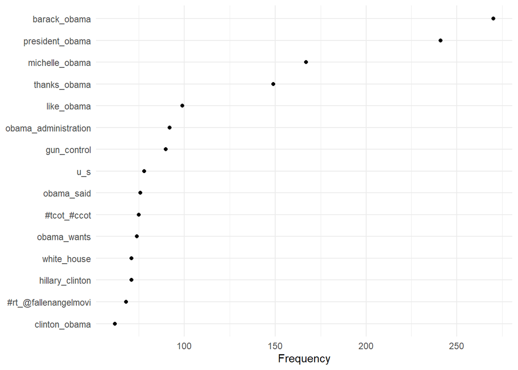

```r
matrizObamaAux %>%
  textstat_frequency(n = 15) %>%
  ggplot(aes(x = reorder(feature, frequency),
             y = frequency)) +
  geom_point() +
  coord_flip() +
  labs(x = NULL,
       y = "Frequency") +
  theme_minimal()
```

Ahora haré lo mismo pero tras las elecciones

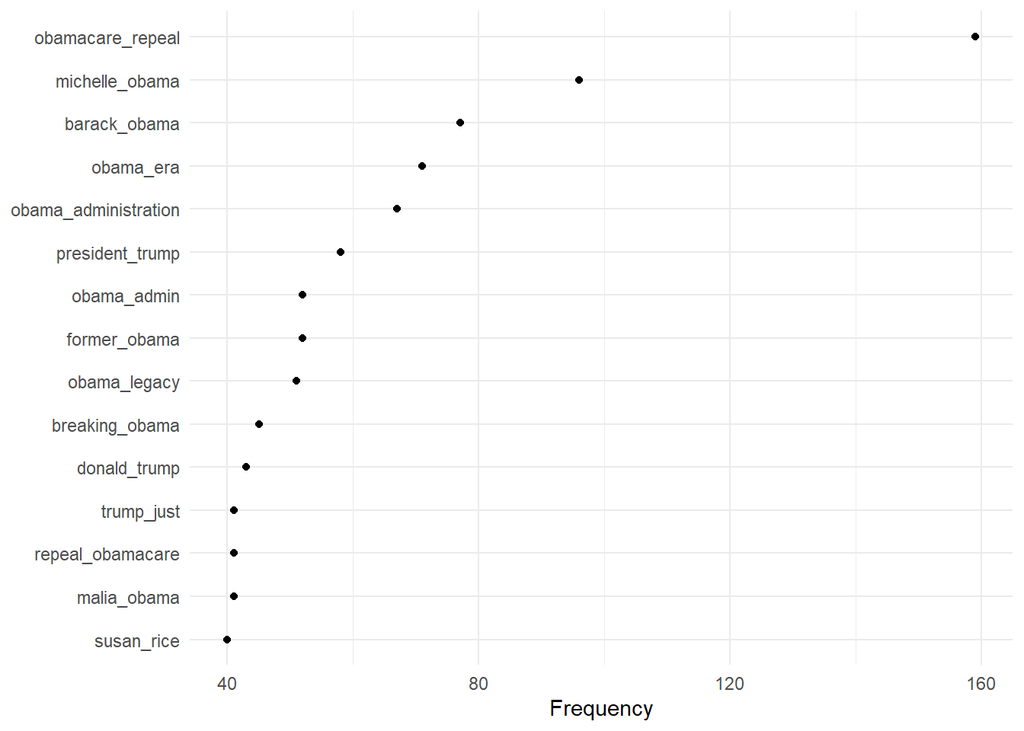

```r
matrizObamaAuxAfter %>%
  textstat_frequency(n = 15) %>%
  ggplot(aes(x = reorder(feature, frequency),
             y = frequency)) +
  geom_point() +
  coord_flip() +
  labs(x = NULL,
       y = "Frequency") +
  theme_minimal()
```

Comprobamos que aquí salen varios temas que ya hemos analizado previamente, pero sobresale uno que no hemos mencionado: “malia_obama”. Malia Ann Obama es una de las hijas de Obama, la cual fue becaria de la productora de cine de los hermanos Weinstein. Tras la quiebra de ésta, se reveló que la productora debía dinero a muchas personas como a los actores Robert de Niro o Jennifer Lawrence y a Malia Obama. Weinstein protagonizó un escándalo de abusos sexuales a nivel mundial, en el que se viralizó el movimiento “Me Too”, que denunciaba los abusos de este productor.

Voy a visualizar a continuación qué bigramas son los que más se repiten independientemente de la fecha

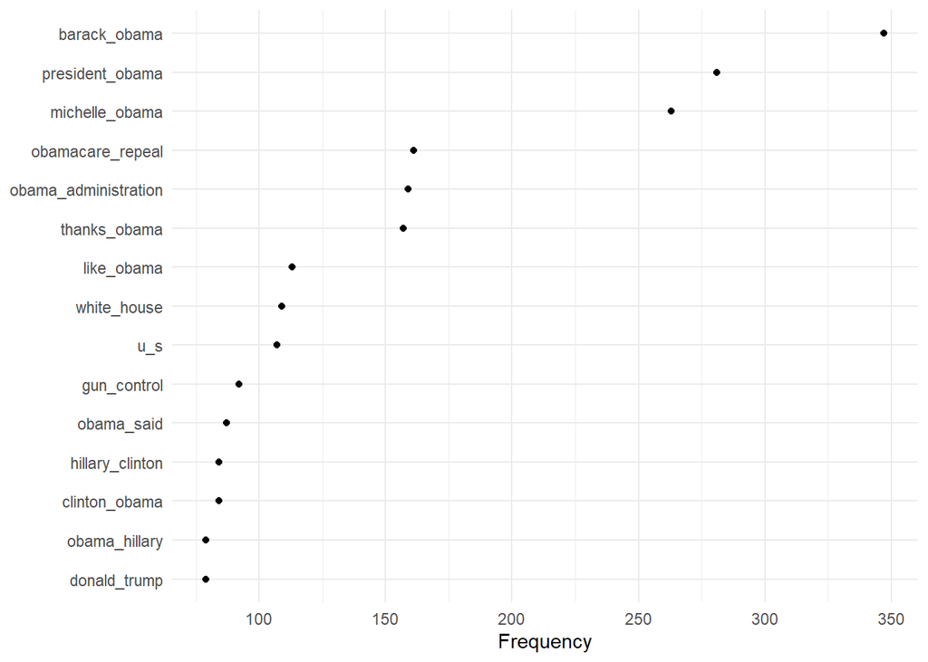

```r
right_tokens_bigrams_noDate <- tokens_subset(bigramas_obama,
                                      (Category == "RightTroll"))


matrizObamaAuxNoDate <- dfm(right_tokens_bigrams_noDate)


matrizObamaAuxNoDate %>%
  textstat_frequency(n = 15) %>%
  ggplot(aes(x = reorder(feature, frequency),
             y = frequency)) +
  geom_point() +
  coord_flip() +
  labs(x = NULL,
       y = "Frequency") +
  theme_minimal()
```

Me gustaría también saber qué hashtags eran los más populares entre trolls de derechas y de izquierdas, y compararlos de forma directa.

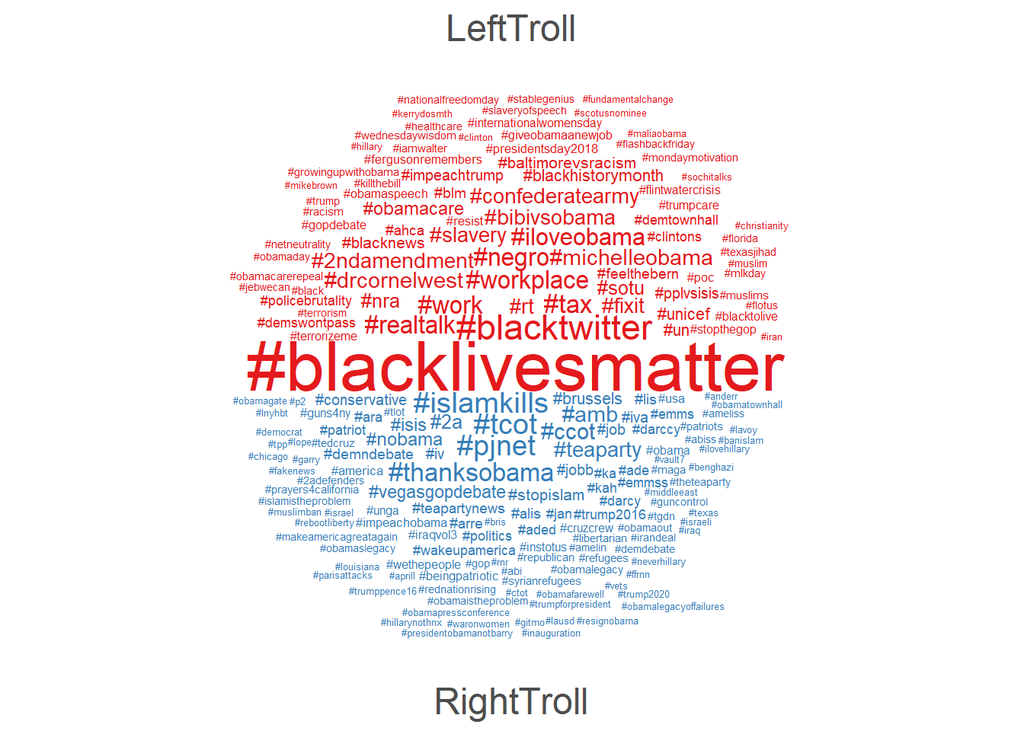

```r
trolls_interesantes <- tokens_subset(obama_tokens,
                                     Category %in% c("RightTroll", "LeftTroll"))

tags <- tokens_select(trolls_interesantes,
                      pattern = "#*")

matriz_compara <- dfm(tags) %>%
    dfm_group(groups = Category)

# create wordcloud
set.seed(132) # set seed for reproducibility

# Usamos escala de color como en topicmodels
# requiere library(RColorBrewer)
# Color palettes here
# https://www.r-graph-gallery.com/38-rcolorbrewers-palettes.html

library(RColorBrewer)

pal2 <- brewer.pal(3,"Set1")

textplot_wordcloud(matriz_compara,
                   comparison = TRUE,
                   max_words = 200,
                   color = pal2,
                   rotation = 0)
```

De este análisis, podemos concluir que los rusos tenían un gran conocimiento acerca de los temas de actualidad estadounidenses, y cómo utilizarlos en su beneficio. El caso de la inferencia rusa en las elecciones estadounidenses de 2016 nos hizo ver lo mucho que puede dañar una campaña de desinformación masiva, y como los rusos han manipulado a favor de sus intereses en redes sociales, como se ha podido ver en otros momentos (como por ejemplo con el tema independentista catalán o las elecciones francesas de 2017). No es de extrañar que Donald Trump y Putin tuviesen buena relación, pues al fin y al cabo, Putin ayudó a Trump a ganar las elecciones de 2016. En esta “era de la información”, debemos estar más atentos que nunca a la desinformación, sobretodo en una época en la que si un tweet dice: “Hemos llegado a Marte”, y tiene muchos likes y retweets, la gente se creerá que es cierto sin contrastar esa información.